# Universidad Autonoma de Aguascalientes

# Departamento: Ciencias de la Computación

## Carrera: Ingenieria en Computación Inteligente

## Curso: Aprendizaje Inteligente (Enero_Junio-2022)

### Maestro:Dr. Francisco Javier Luna Rosas

### Román Guadalupe De León Vázquez

### Jesús Alejandro Martínez Martínez¶

### Samuel Alejandro Núñez Montaño

### Juan Abraham Ortíz Salas

### Debemos de tener instalados algunos complementos en python como el Facebook Scraper y la lista de cookies para que este funcione y nos de el dataset

```python
from facebook_scraper import get_posts
import pandas as pd
import matplotlib.pyplot as plt
import seaborn as sns
from facebook_scraper import *

set_user_agent("Mozilla/5.0 (compatible; Googlebot/2.1; +http://www.google.com/bot.html)")
```

### Inicializamos el Dataset

```python
post_df_full = pd.DataFrame(columns = [])
```

### Ejecutamos la libreria para recolectar los datos de las publicaciones en este caso de la BBC

```python
for post in get_posts('bbcnews', cookies='cookies.json', extra_info=True, pages=5, options={"comments": True}):
    post_entry = post
    fb_post_df = pd.DataFrame.from_dict(post_entry, orient='index')
    fb_post_df = fb_post_df.transpose()
    post_df_full = post_df_full.append(fb_post_df)
    print(post['post_id']+' get')
```

```
391116816385650 get
```

```
391091303054868 get
```

```
391066216390710 get
```

```
391041793059819 get
```

```
391016896395642 get
```

```
390995073064491 get
```

```
390975189733146 get
```

```
390959546401377 get
```

```
390942563069742 get
390916709738994 get
```

### Revisamos la informacion y la guardamos en el csv para su uso

```python
post_df_full.info()
```

```
<class 'pandas.core.frame.DataFrame'>
Int64Index: 10 entries, 0 to 0
Data columns (total 51 columns):
 #   Column                         Non-Null Count  Dtype
---  ------                         --------------  -----
 0   post_id                        10 non-null     object
 1   text                           10 non-null     object
 2   post_text                      10 non-null     object
 3   shared_text                    10 non-null     object
 4   original_text                  10 non-null     object
 5   time                           10 non-null     datetime64[ns]
 6   timestamp                      10 non-null     object
 7   image                          10 non-null     object
 8   image_lowquality               10 non-null     object
 9   images                         10 non-null     object
```

[output cut: 43 more lines]

```python
post_df_full.head()
```

|  | post_id | text | post_text | shared_text | original_text | time | timestamp | image | image_lowquality | images | ... | w3_fb_url | reactions | reaction_count | with | page_id | sharers | image_id | image_ids | was_live | header |
| --- | --- | --- | --- | --- | --- | --- | --- | --- | --- | --- | --- | --- | --- | --- | --- | --- | --- | --- | --- | --- | --- |
| 0 | 391116816385650 | "I think this is all about spectacle, about cu... | "I think this is all about spectacle, about cu... | BBC.COM\nHyper-real whale model appears on UK ... |  | 2022-05-26 23:04:07 | 1653624247 | https://ichef.bbci.co.uk/news/1024/branded_new... | https://external.fagu3-1.fna.fbcdn.net/safe_im... | [https://ichef.bbci.co.uk/news/1024/branded_ne... | ... | None | None | None | [{'name': 'BBC News 1 h · "We're going to swap... | 228735667216 | None | None | [] | False | BBC News\n22 min ·\n"I think this is all about... |
| 0 | 391091303054868 | "We're going to swap violence for freedom and ... | "We're going to swap violence for freedom and ... | BBC.COM\nSpanish MPs back 'only yes means yes'... |  | 2022-05-26 22:02:10 | 1653620530 | https://ichef.bbci.co.uk/news/1024/branded_new... | https://external.fagu3-1.fna.fbcdn.net/safe_im... | [https://ichef.bbci.co.uk/news/1024/branded_ne... | ... | None | None | None | [{'name': 'BBC News 2 h · With fighting intens... | 228735667216 | None | None | [] | False | BBC News\n1 h ·\n"We're going to swap violence... |
| 0 | 391066216390710 | With fighting intensifying in eastern Ukraine,... | With fighting intensifying in eastern Ukraine,... | BBC.COM\nWhy is Russia trying to capture easte... |  | 2022-05-26 21:02:06 | 1653616926 | https://ichef.bbci.co.uk/news/1024/branded_new... | https://external.fagu3-1.fna.fbcdn.net/safe_im... | [https://ichef.bbci.co.uk/news/1024/branded_ne... | ... | None | None | None | [{'name': 'BBC News 3 h · The National Rifle A... | 228735667216 | None | None | [] | False | BBC News\n2 h ·\nWith fighting intensifying in... |
| 0 | 391041793059819 | The National Rifle Association spends about $3... | The National Rifle Association spends about $3... | BBC.COM\nWhat is the NRA and why is it so powe... |  | 2022-05-26 20:02:20 | 1653613340 | https://ichef.bbci.co.uk/news/1024/branded_new... | https://external.fagu3-1.fna.fbcdn.net/safe_im... | [https://ichef.bbci.co.uk/news/1024/branded_ne... | ... | None | None | None | [{'name': 'BBC News 4 h · "I was told the terr... | 228735667216 | None | None | [] | False | BBC News\n3 h ·\nThe National Rifle Associatio... |
| 0 | 391016896395642 | "I was told the terrifying news: 'Your childre... | "I was told the terrifying news: 'Your childre... | BBC.COM\nRussian mother's fight to save sons f... |  | 2022-05-26 19:04:10 | 1653609850 | https://ichef.bbci.co.uk/news/1024/branded_new... | https://external.fagu3-1.fna.fbcdn.net/safe_im... | [https://ichef.bbci.co.uk/news/1024/branded_ne... | ... | None | None | None | [{'name': 'BBC News 5 h · "We’re expected to p... | 228735667216 | None | None | [] | False | BBC News\n4 h ·\n"I was told the terrifying ne... |

5 rows × 51 columns

```python
# Save dataframe into csv file
post_df_full.to_csv(r'fb_BBC_scrapped_data.csv', index = False)
```

### Ejecutamos una linea de tiempo sencilla solo con el conteo de reacciones

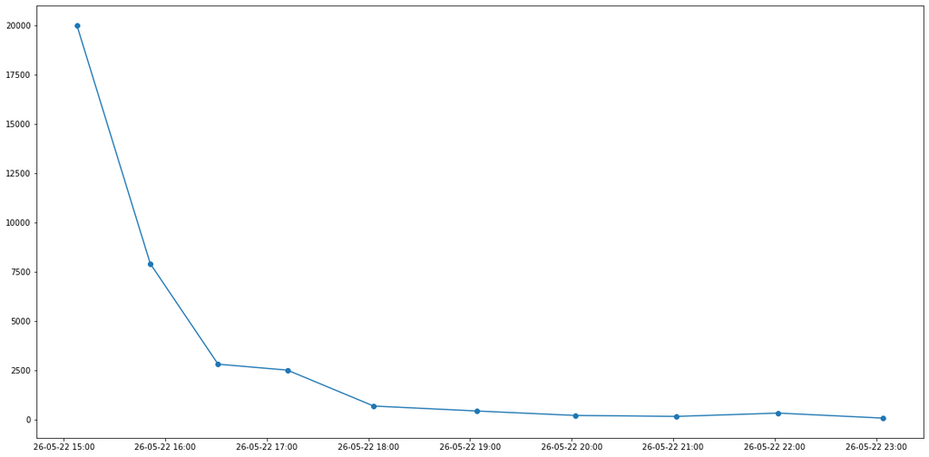

```python
fig, ax = plt.subplots(figsize=(20, 10))
ax.plot(post_df_full['time'], post_df_full['likes'], marker="o")
from matplotlib.dates import DateFormatter
ax.xaxis.set_major_formatter(DateFormatter('%d-%m-%y %H:%M'))
```

### Ahora Ejecutamos una diferenciando las reacciones de los comentarios y las compartidas

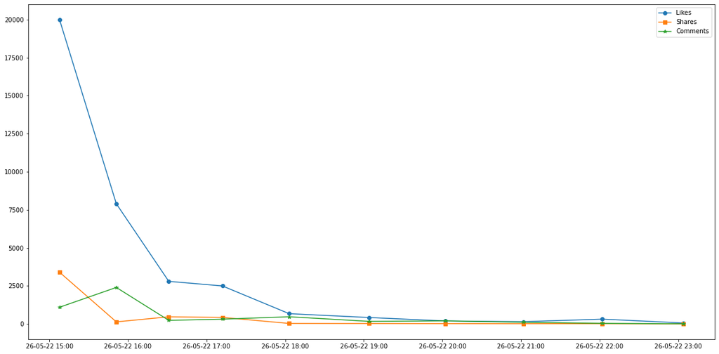

```python
fig, ax = plt.subplots(figsize=(20, 10))
ax.plot(post_df_full['time'], post_df_full['likes'], label = "Likes", marker="o")
ax.plot(post_df_full['time'], post_df_full['shares'], label = "Shares", marker="s")
ax.plot(post_df_full['time'], post_df_full['comments'], label = "Comments", marker="*")
plt.legend()
from matplotlib.dates import DateFormatter
ax.xaxis.set_major_formatter(DateFormatter('%d-%m-%y %H:%M'))
```

### Recargamos el CSV con los datos limpios

```python
post_df_full_csv = pd.read_csv("fb_BBC_scrapped_data.csv")
post_df_full_csv['time'] = pd.to_datetime(post_df_full_csv['time'])
```

```python
post_df_full_csv.head()
```

|  | post_id | text | post_text | shared_text | original_text | time | timestamp | image | image_lowquality | images | ... | w3_fb_url | reactions | reaction_count | with | page_id | sharers | image_id | image_ids | was_live | header |
| --- | --- | --- | --- | --- | --- | --- | --- | --- | --- | --- | --- | --- | --- | --- | --- | --- | --- | --- | --- | --- | --- |
| 0 | 391116816385650 | "I think this is all about spectacle, about cu... | "I think this is all about spectacle, about cu... | BBC.COM\nHyper-real whale model appears on UK ... | NaN | 2022-05-26 23:04:07 | 1653624247 | https://ichef.bbci.co.uk/news/1024/branded_new... | https://external.fagu3-1.fna.fbcdn.net/safe_im... | ['https://ichef.bbci.co.uk/news/1024/branded_n... | ... | NaN | NaN | NaN | [{'name': 'BBC News\n1 h ·\n"We\'re going to s... | 228735667216 | NaN | NaN | [] | False | BBC News\n22 min ·\n"I think this is all about... |
| 1 | 391091303054868 | "We're going to swap violence for freedom and ... | "We're going to swap violence for freedom and ... | BBC.COM\nSpanish MPs back 'only yes means yes'... | NaN | 2022-05-26 22:02:10 | 1653620530 | https://ichef.bbci.co.uk/news/1024/branded_new... | https://external.fagu3-1.fna.fbcdn.net/safe_im... | ['https://ichef.bbci.co.uk/news/1024/branded_n... | ... | NaN | NaN | NaN | [{'name': 'BBC News\n2 h ·\nWith fighting inte... | 228735667216 | NaN | NaN | [] | False | BBC News\n1 h ·\n"We're going to swap violence... |
| 2 | 391066216390710 | With fighting intensifying in eastern Ukraine,... | With fighting intensifying in eastern Ukraine,... | BBC.COM\nWhy is Russia trying to capture easte... | NaN | 2022-05-26 21:02:06 | 1653616926 | https://ichef.bbci.co.uk/news/1024/branded_new... | https://external.fagu3-1.fna.fbcdn.net/safe_im... | ['https://ichef.bbci.co.uk/news/1024/branded_n... | ... | NaN | NaN | NaN | [{'name': 'BBC News\n3 h ·\nThe National Rifle... | 228735667216 | NaN | NaN | [] | False | BBC News\n2 h ·\nWith fighting intensifying in... |
| 3 | 391041793059819 | The National Rifle Association spends about $3... | The National Rifle Association spends about $3... | BBC.COM\nWhat is the NRA and why is it so powe... | NaN | 2022-05-26 20:02:20 | 1653613340 | https://ichef.bbci.co.uk/news/1024/branded_new... | https://external.fagu3-1.fna.fbcdn.net/safe_im... | ['https://ichef.bbci.co.uk/news/1024/branded_n... | ... | NaN | NaN | NaN | [{'name': 'BBC News\n4 h ·\n"I was told the te... | 228735667216 | NaN | NaN | [] | False | BBC News\n3 h ·\nThe National Rifle Associatio... |
| 4 | 391016896395642 | "I was told the terrifying news: 'Your childre... | "I was told the terrifying news: 'Your childre... | BBC.COM\nRussian mother's fight to save sons f... | NaN | 2022-05-26 19:04:10 | 1653609850 | https://ichef.bbci.co.uk/news/1024/branded_new... | https://external.fagu3-1.fna.fbcdn.net/safe_im... | ['https://ichef.bbci.co.uk/news/1024/branded_n... | ... | NaN | NaN | NaN | [{'name': 'BBC News\n5 h ·\n"We’re expected to... | 228735667216 | NaN | NaN | [] | False | BBC News\n4 h ·\n"I was told the terrifying ne... |

5 rows × 51 columns

### Empezamos con la red de prediccion

```python
import pandas as pd
import numpy as np
import matplotlib.pylab as plt
#%matplotlib inline
#plt.rcParams['figure.figsize'] = (16, 9)
#plt.style.use('fast')
import tensorflow as tf
from tensorflow import keras
from tensorflow.keras import layers
import os
from keras.models import Sequential
from keras.layers import Dense,Activation,Flatten
from sklearn.preprocessing import MinMaxScaler
from sklearn.preprocessing import StandardScaler

from keras.layers.core import Dense, Dropout
from keras.layers import LSTM
```

```python
os.chdir("/home/romanrj/Documentos/Aprendizaje Inteligente")
datos = pd.read_csv('fb_BBC_scrapped_data.csv')
datos.head
```

[output not shown]

[output cut: 206 more lines]

```python
print(datos.head())
```

```
             post_id                                               text  \
0  10159060367757217  An unprecedented challenge made by Poland's pr...
1  10159060276847217  "Thoughout the pandemic we have no been traini...
2  10159060300562217  "The safety of the audience and touring crew h...
3  10159060232517217  "If you think you have Covid, even if the PCR ...
4  10159060158237217  "This could have been fatal."\n\nBBC.COM\nDog ...

                                           post_text  \
0  An unprecedented challenge made by Poland's pr...
1  "Thoughout the pandemic we have no been traini...
2  "The safety of the audience and touring crew h...
3  "If you think you have Covid, even if the PCR ...
4                      "This could have been fatal."

                                         shared_text  \
```

[output cut: 63 more lines]

```python
datos.describe()
```

|  | post_id | timestamp | video_duration_seconds | video_height | video_id | video_quality | video_size_MB | video_watches | video_width | likes | ... | user_id | factcheck | shared_post_id | shared_time | shared_user_id | shared_username | shared_post_url | reaction_count | with | image_id |
| --- | --- | --- | --- | --- | --- | --- | --- | --- | --- | --- | --- | --- | --- | --- | --- | --- | --- | --- | --- | --- | --- |
| count | 1.800000e+01 | 1.800000e+01 | 0.0 | 0.0 | 2.000000e+00 | 0.0 | 0.0 | 0.0 | 0.0 | 18.000000 | ... | 1.800000e+01 | 0.0 | 0.0 | 0.0 | 0.0 | 0.0 | 0.0 | 18.000000 | 0.0 | 0.0 |
| mean | 1.015906e+16 | 1.633750e+09 | NaN | NaN | 9.529200e+14 | NaN | NaN | NaN | NaN | 1336.388889 | ... | 2.287357e+11 | NaN | NaN | NaN | NaN | NaN | NaN | 2435.555556 | NaN | NaN |
| std | 3.221795e+08 | 1.954913e+04 | NaN | NaN | 9.245647e+13 | NaN | NaN | NaN | NaN | 1955.586722 | ... | 0.000000e+00 | NaN | NaN | NaN | NaN | NaN | NaN | 2917.003503 | NaN | NaN |
| min | 1.015906e+16 | 1.633722e+09 | NaN | NaN | 8.875434e+14 | NaN | NaN | NaN | NaN | 173.000000 | ... | 2.287357e+11 | NaN | NaN | NaN | NaN | NaN | NaN | 182.000000 | NaN | NaN |
| 25% | 1.015906e+16 | 1.633732e+09 | NaN | NaN | 9.202317e+14 | NaN | NaN | NaN | NaN | 254.750000 | ... | 2.287357e+11 | NaN | NaN | NaN | NaN | NaN | NaN | 368.500000 | NaN | NaN |
| 50% | 1.015906e+16 | 1.633750e+09 | NaN | NaN | 9.529200e+14 | NaN | NaN | NaN | NaN | 590.000000 | ... | 2.287357e+11 | NaN | NaN | NaN | NaN | NaN | NaN | 1224.500000 | NaN | NaN |
| 75% | 1.015906e+16 | 1.633767e+09 | NaN | NaN | 9.856083e+14 | NaN | NaN | NaN | NaN | 1314.750000 | ... | 2.287357e+11 | NaN | NaN | NaN | NaN | NaN | NaN | 3405.000000 | NaN | NaN |
| max | 1.015906e+16 | 1.633778e+09 | NaN | NaN | 1.018297e+15 | NaN | NaN | NaN | NaN | 7790.000000 | ... | 2.287357e+11 | NaN | NaN | NaN | NaN | NaN | NaN | 9869.000000 | NaN | NaN |

8 rows × 22 columns

```python
print(datos.index.min())
print(datos.index.max())
```

```
0
17
```

### Separamos la informacion que nos interesa como el conteo de reacciones y sus respectivas fechas

```python
training = datos.iloc[0:12,42:43]
testing = datos.iloc[12:17,42:43]
print(training)
print("\n",testing)
```

```
    reaction_count
0              335
1              182
2             1167
3             9869
4             1945
5             3556
6              376
7              262
8             3953
9             1282
10            4901
11            2470

     reaction_count
12            8889
13             453
14             366
15             576
16             306
```

```python
ytime = datos.iloc[:,4:5]
print(ytime.head())
```

```
                         time
0  2021-10-09 19:20:37.000000
1  2021-10-09 18:50:40.000000
2  2021-10-09 18:21:08.000000
3  2021-10-09 17:20:57.000000
4  2021-10-09 16:22:07.000000
```

[figure not shown]

```python
plt.plot(datos['time'],datos['reaction_count'],'o-')
```

### Procesamos los datos para mejor manejo

```python
print("Datos sin estandarizar\n",training)

#escalamos los datos
scaler = StandardScaler()
sc_training = scaler.fit_transform(X)
print("\nDatos estandarizados\n",sc_training)
```

```
Datos sin estandarizar
     reaction_count
0              335
1              182
2             1167
3             9869
4             1945
5             3556
6              376
7              262
8             3953
9             1282
10            4901
11            2470

Datos estandarizados
 [[-0.74098431]
 [-0.79495603]
 [-0.44749103]
 [ 2.62219474]
 [-0.17304659]
 [ 0.39524389]
 [-0.7265213 ]
 [-0.76673553]
 [ 0.53528816]
 [-0.40692405]
 [ 0.86970119]
 [ 0.0121505 ]
 [ 2.27649351]
 [-0.69935906]
 [-0.73004887]
 [-0.65597003]
 [-0.75121425]
 [ 0.18217906]]
```

```python
PASOS = 3

#separamos en X y Y datos de training
X_train = []
Y_train = []

m = len(sc_training)

for i in range (PASOS,m):
    X_train.append(sc_training[i-PASOS:i,0])
    Y_train.append(sc_training[i,0])

X_train, Y_train = np.array(X_train), np.array(Y_train)

print("Secuencia X_train\n",X_train[0][:])
print("\nSecuencia Y_train\n",Y_train[0])
```

```
Secuencia X_train
 [-0.74098431 -0.79495603 -0.44749103]

Secuencia Y_train
 2.62219473554034
```

```python
#set de testing normalizmos los datos
x_test = testing.values
x_test = scaler.transform(x_test)

X_test = []
for i in range(PASOS,len(x_test)):
    X_test.append(x_test[i-PASOS:i,0])

X_test = np.array(X_test)
X_test = np.reshape(X_test, (X_test.shape[0],X_test.shape[1],1))

X_train = np.reshape(X_train, (X_train.shape[0],X_train.shape[1],1))

print("X_train.shape",X_train.shape)
print("X_test.shape",X_test.shape)
print("\n",X_train[0])
```

```
X_train.shape (15, 3, 1)
X_test.shape (2, 3, 1)

 [[-0.74098431]
 [-0.79495603]
 [-0.44749103]]
```

## Creamos el Modelo de Red Neuronal (lo bueno)

### Modelo RNN

```python
dim_entrada = (X_train.shape[1],1)

modelo = Sequential()
modelo.add(LSTM(units=124, input_shape=dim_entrada))
modelo.add(Dense(units=62, activation = "sigmoid"))
modelo.add(Dense(units=1, activation = "relu"))

modelo.compile(optimizer="adam", loss="mse")

modelo.summary()
```

```
Model: "sequential_4"
_________________________________________________________________
 Layer (type)                Output Shape              Param #
=================================================================
 lstm_3 (LSTM)               (None, 124)               62496

 dense_6 (Dense)             (None, 62)                7750

 dense_7 (Dense)             (None, 1)                 63

=================================================================
Total params: 70,309
Trainable params: 70,309
Non-trainable params: 0
_________________________________________________________________
```

### Entrenamos nuestra red

```python
modelo.fit(X_train, Y_train, epochs=30, batch_size=32, verbose= 0)
```

```
<keras.callbacks.History at 0x7f2068b40250>
```

### Revisamos resultados

```python
prediccion = modelo.predict(X_test)
#aplicamos la normaizacion inversa a la prediccion
prediccion = scaler.inverse_transform(prediccion)
```

### Insertamos el grafico

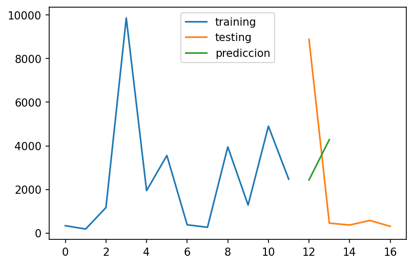

```python
fig, ax= plt.subplots(1,1, figsize = (6,4), dpi=150)

plt.plot(training.index, training.values, label="training")
plt.plot(testing.index, testing.values, label="testing")
plt.plot(testing.index[0:len(X_test)], prediccion, label="prediccion")
plt.legend()
```

## Conclusiones:

### Fue un problema el elegir una red social bastante protegida como Facebook, pudimos comprobar que sus datos estan seguros al intentar sacar un dataset de grupos y perfiles privados, y al ser batsante reducida la informacion no llegamos a tener una buena prediccion, el dataset se puede dejar por horas y nos ayudaria a llegar a datos mas prescisos pero por lo pronto estos son los resultados

## Referencias

### Kevin Zuñiga. (2022). Facebook Web Scraper. 19 de Mayo 2022, de Pipy Sitio web: https://pypi.org/project/facebook-scraper/

### Nicolás Puentes. (2021). Predicción con Machine Learning utilizando Python. 22 de Mayo de 2022, de Nebulova Sitio web: https://www.nebulova.es/blog/prediccion-machine-learning-python

### Raul E. Lopez Briega. (2015). Machine Learning con Python. 22 de Mayo de 2022, de Raul E. Lopez Briega Sitio web: https://relopezbriega.github.io/blog/2015/10/10/machine-learning-con-python/

### Desconocido. (2019). Pronóstico de Ventas con Redes Neuronales. 25 de Mayo 2022, de Aprende Machine Learning Sitio web: https://www.aprendemachinelearning.com/pronostico-de-ventas-redes-neuronales-python-embeddings/